# Biostat 212a Homework 1

Due Jan 23, 2024 @ 11:59PM

Author

Wenqing Mao, UID:806332971

Published

January 23, 2024

## 1 Filling gaps in lecture notes (10pts)

Consider the regression model
$$Y = f(X) + \epsilon,$$
where $\operatorname{E}(\epsilon) = 0$.

### 1.1 Optimal regression function

Show that the choice
$$f_{\text{opt}}(X) = \operatorname{E}(Y | X)$$
minimizes the mean squared prediction error
$$\operatorname{E}\{[Y - f(X)]^2\},$$
where the expectations averages over variations in both $X$ and $Y$. (Hint: condition on $X$.)

**Answer:**

According to the law of iterated expectation, we have

$$\operatorname{E}\{[Y - f(X)]^2\} = \operatorname{E}\{\operatorname{E}\{[Y - f(X)]^2|X\}\}$$
As expectation is a linear operator, to minimize $\operatorname{E}\{[Y - f(X)]^2\}$, we only need to minimize the inner expectation $\operatorname{E}\{[Y - f(X)]^2|X\}$ for each $x_i$. That is

$$f(X) = argmin_{f(X)}\operatorname{E}\{[Y - f(X)]^2|X\}$$

Decompose the inner expecation by adding and subtracting $\operatorname{E}(Y|X)$:

$$\begin{align}
\operatorname{E}\{[Y - f(X)]^2|X\} &= \operatorname{E}\{[Y - \operatorname{E}(Y|X) + \operatorname{E}(Y|X) - f(X)]^2|X\}\\
&=\operatorname{E}\{[Y - \operatorname{E}(Y|X)]^2|X\}+\operatorname{E}\{[\operatorname{E}(Y|X) - f(X)]^2|X\}\\
&+2\operatorname{E}\{[Y - \operatorname{E}(Y|X)]|X\}\operatorname{E}\{[\operatorname{E}(Y|X) - f(X)]|X\}
\end{align}$$
Let’s focus on the last term. As $\operatorname{E}(Y|X) - f(X)$ is a constant given $X$, we can pull it outside the expectation and get
$$\begin{align}
&2(\operatorname{E}(Y|X) - f(X))\operatorname{E}\{[Y - \operatorname{E}(Y|X)]|X\}\\
&=\underbrace{2(\operatorname{E}(Y|X) - f(X))}_{\text{constant}}[\operatorname{E}(Y|X)-\operatorname{E}[\operatorname{E}(Y|X)|X]]\\
&=\underbrace{2(\operatorname{E}(Y|X) - f(X))}_{\text{constant}}[\operatorname{E}(Y|X)-\operatorname{E}(Y|X)]\\
&=0
\end{align}$$
$\operatorname{E}[\operatorname{E}(Y|X)|X]=\operatorname{E}(Y|X)$ is because $\operatorname{E}(Y|X)$ is a constant given $X$.

Thus, we have
$$\begin{align}
\operatorname{E}\{[Y - f(X)]^2|X\} &= \operatorname{E}\{[Y - \operatorname{E}(Y|X)]^2|X\}+\operatorname{E}\{[\operatorname{E}(Y|X) - f(X)]^2|X\}\\
\end{align}$$
The only term that depends on $f(X)$ is the second term. Thus, to minimize $\operatorname{E}\{[Y - f(X)]^2|X\}$, we only need to minimize the second term. That is $f(X) = \operatorname{E}(Y|X)$.

### 1.2 Bias-variance trade-off

Given an estimate $\hat f$ of $f$, show that the test error at a $x_0$ can be decomposed as
$$\operatorname{E}\{[y_0 - \hat f(x_0)]^2\} = \underbrace{\operatorname{Var}(\hat f(x_0)) + [\operatorname{Bias}(\hat f(x_0))]^2}_{\text{MSE of } \hat f(x_0) \text{ for estimating } f(x_0)} + \underbrace{\operatorname{Var}(\epsilon)}_{\text{irreducible}},$$
where the expectation averages over the variability in $y_0$ and $\hat f$.

**Answer:**

Since $y_{0} =f(x_{0})+\epsilon$, we plug in $y_{0}$ and get

$$\begin{align}
\operatorname{E}\{[y_0 - \hat f(x_0)]^2&=\operatorname{E}\{[f(x_{0})+\epsilon - \hat f(x_0)]^2\}\\
&=\operatorname{E}\{[f(x_{0}) - \hat f(x_0)]^2\}+\operatorname{E}\{\epsilon^2\}+2\underbrace{\operatorname{E}\{[f(x_{0}) - \hat f(x_0)]\epsilon\}}_{=\operatorname{E}\{f(x_{0}) - \hat f(x_0)\}\operatorname{E}\{\epsilon\}=0}\\
&=\operatorname{E}\{[f(x_{0}) - \hat f(x_0)]^2\}+\operatorname{E}\{\epsilon^2\}\\
&=\operatorname{E}\{[f(x_{0}) - \hat f(x_0)]^2\}+\operatorname{Var}(\epsilon)\\
\end{align}$$
Decompose the first term by adding and subtracting $\operatorname{E}(\hat f(x_0))$:

$$\begin{align}
\operatorname{E}\{[f(x_{0}) - \hat f(x_0)]^2\}&=\operatorname{E}\{[f(x_{0}) - \operatorname{E}(\hat f(x_0))+\operatorname{E}(\hat f(x_0)) - \hat f(x_0)]^2\}\\
&=\operatorname{E}\{[f(x_{0}) - \operatorname{E}(\hat f(x_0))]^2\}+\operatorname{E}\{[\operatorname{E}(\hat f(x_0)) - \hat f(x_0)]^2\}+2\operatorname{E}\{[f(x_{0}) - \operatorname{E}(\hat f(x_0))][\operatorname{E}(\hat f(x_0)) - \hat f(x_0)]\}
\end{align}$$
Let’s focus on the cross term. As $\hat f(x_0)$ is a constant, we have $\operatorname{E}(\hat f(x_0)) - \hat f(x_0)=0$, so the cross term is 0. Then we have

$$\begin{align}
\operatorname{E}\{[f(x_{0}) - \hat f(x_0)]^2\}&=\operatorname{E}\{[f(x_{0}) - \operatorname{E}(\hat f(x_0))]^2\}+\operatorname{E}\{[\operatorname{E}(\hat f(x_0)) - \hat f(x_0)]^2\}\\
&=\operatorname{Bias}(\hat f(x_0))^2+\operatorname{Var}(\hat f(x_0))\\
\end{align}$$
where $\operatorname{Bias}(\hat f(x_0)) = \operatorname{E}[\hat f(x_0)] - f(x_0)$.

Finally, we prove that

$$\operatorname{E}\{[y_0 - \hat f(x_0)]^2\} = \operatorname{Var}(\hat f(x_0)) + [\operatorname{Bias}(\hat f(x_0))]^2 + \operatorname{Var}(\epsilon)$$

## 2 ISL Exercise 2.4.3 (10pts)

**(a) Plot five curves**

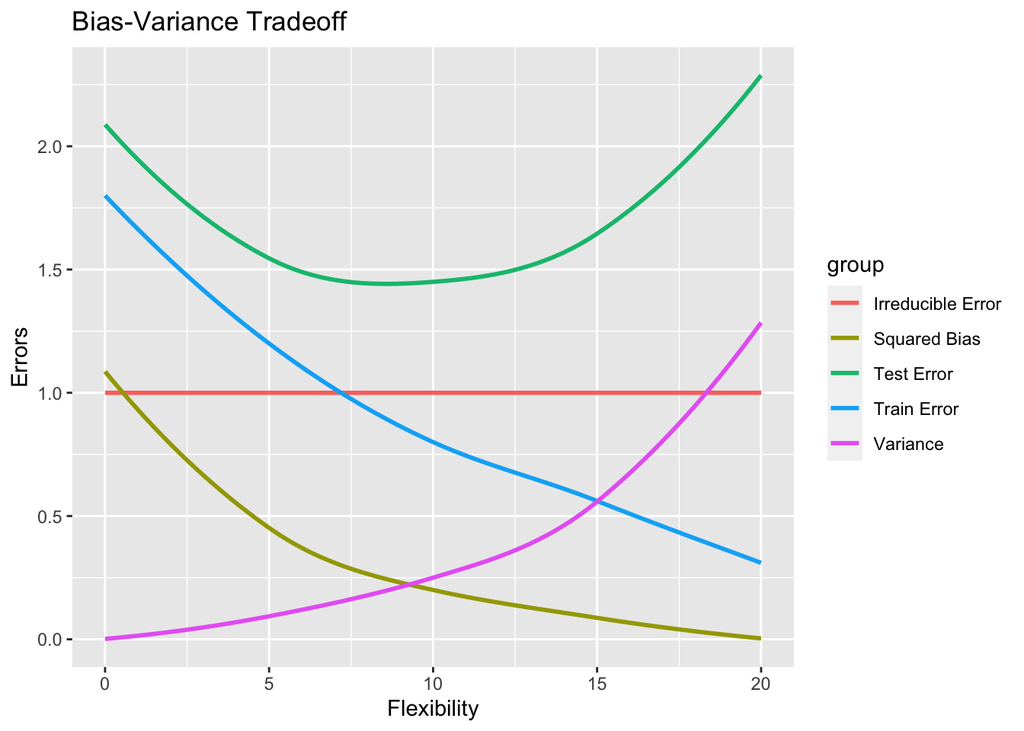

```r
library(ggplot2)
bias_squared = c(1.1, 0.4, 0.2, 0.1, 0)
variance = c(0, 0.1, 0.25, 0.5, 1.3)
bayes_error = c(1, 1, 1, 1, 1)
test_error = bias_squared + variance + bayes_error
train_error = c(1.8, 1.2, 0.8, 0.6, 0.3)

curves <- data.frame(x = seq(0, 20, 5),
                     y = c(bias_squared, variance, bayes_error, test_error, train_error),
                     group = rep(c("Squared Bias", "Variance","Irreducible Error", "Test Error", "Train Error"), each = 5))

ggplot(data = curves, aes(x = x, y = y, color=group)) +
  geom_smooth(method = "loess", span=1, se = F) +
  xlab("Flexibility") +
  ylab("Errors") +
  ggtitle("Bias-Variance Tradeoff")
```

**(b) Explaination**

- Irriducible error (red line): The error that can’t be reduced by any model no matter how complex it is. This error is caused by the noise in the data generation process and are irrelevent to the model, so it is a contant line in the plot.
- Squared bias (yellow curve): The error appears because the simplified model can not capture the true relationship between predictors and response in the real-world. This error can be reduced by using more complex models, so the yellow curve is decreasing as the model becomes more flexible.
- Variance (pink curve): Variance refers to the sensitivity of the model to fluctuations in the training data. This error appears because a too complex model may overfit the training data, that is, a small fluctuation in the training data may cause a large change in the model. Thus, it is a increasing curve as the model becomes more flexible.
- Test error (green curve): The test error is the sum of squared bias, variance and irreducible error. It is the sum of the yellow, pink and red curves in the plot. It is a U-shaped curve, because the squared bias is decreasing while the variance is increasing as the model becomes more flexible.
- Train error (blue curve): It refers to the error of the model on the same data it was trained on. It is entirely possible for the training error to be very low, especially if the model is complex enough to fit all the training data points perfectly. So, the blue curve is monotonically decreasing as the model becomes more flexible.

## 3 ISL Exercise 2.4.4 (10pts)

**(a) Describe three real-life applications in which classification might be useful. Describe the response, as well as the predictors. Is the goal of each application inference or prediction? Explain your answer.**

**Answer:**

- Default detection in commercial banks. The response is whether a customer will default, and the predictors are customer’s age, income, credit history, etc. The goal is prediction, because the bank wants to predict whether a customer will default, and then decide whether to approve or deny the loan request from the customer.
- Biostatisticians use classification model to determine whether a individual has a disease based on his/her symptoms. The response is whether a individual has a disease, and the predictors are individual’s symptom details. The goal is prediction, because the doctor wants to predict whether a individual get infected with a certain disease, and treat them accordingly.
- Zoologists use classification model to determine an wild animal’s species. The response is the animal’s species, and the predictors are animal’s physical features. This is a inference problem when the zoologist wants to know which features are most important for distinguishing between species, and then can use these features to determine the species of a new animal or unclassified ones.

**(b) Describe three real-life applications in which regression might be useful. Describe the response, as well as the predictors. Is the goal of each application inference or prediction? Explain your answer.**

**Answer:**

- Insurance companies usually use regression to predict individual’s healthcare expenses. The response is healthcare expense amount, and the predictors are individual’s age, smoking history, alcohol use, etc. The goal is prediction, because the insurance company wants to predict their expense amount, and then charge them accordingly.
- Investment companies usually use regression to predict stock price. The response is stock price, and the predictors are company’s fundamental information, financial report, moving average price, momentum, etc. The goal is prediction, because the investment company wants to predict the stock price, and then decide whether to buy or sell the stock.
- Analysis GDP of a country. The response is GDP, and the predictors are population, interest rates, unemployment rate, etc. The goal is inference, as economists want to know how different macroeconomic variables affect GDP, which group of variables are more important to a country, and will changing a certain variable increase the GDP?

**(c) Describe three real-life applications in which cluster analysis might be useful.**

**Answer:**

- Gene expression analysis in Bioinformatics. Cluster analysis can be used to group genes with similar expression patterns. This can help biologists to understand the function of genes.
- Market segmentation in E-commerce companies. Cluster analysis can be used to group customers with similar purchasing behavior. This can help companies to identify their target customers.
- Image Segmentation in Computer Vision. Cluster analysis can be used to group pixels with similar color, texture or intensity. This can help computer to understand the content of an image.

## 4 ISL Exercise 2.4.10 (30pts)

Your can read in the `boston` data set directly from url https://raw.githubusercontent.com/ucla-biostat-212a/2024winter/master/slides/data/Boston.csv. A documentation of the `boston` data set is [here](https://www.rdocumentation.org/packages/ISLR2/versions/1.3-2/topics/Boston).

**R**

```r
library(tidyverse)

Boston <- read_csv("https://raw.githubusercontent.com/ucla-biostat-212a/2024winter/master/slides/data/Boston.csv", col_select = -1) %>%
  print(width = Inf)
```

```
# A tibble: 506 × 13
      crim    zn indus  chas   nox    rm   age   dis   rad   tax ptratio lstat
     <dbl> <dbl> <dbl> <dbl> <dbl> <dbl> <dbl> <dbl> <dbl> <dbl>   <dbl> <dbl>
 1 0.00632  18    2.31     0 0.538  6.58  65.2  4.09     1   296    15.3  4.98
 2 0.0273    0    7.07     0 0.469  6.42  78.9  4.97     2   242    17.8  9.14
 3 0.0273    0    7.07     0 0.469  7.18  61.1  4.97     2   242    17.8  4.03
 4 0.0324    0    2.18     0 0.458  7.00  45.8  6.06     3   222    18.7  2.94
 5 0.0690    0    2.18     0 0.458  7.15  54.2  6.06     3   222    18.7  5.33
 6 0.0298    0    2.18     0 0.458  6.43  58.7  6.06     3   222    18.7  5.21
 7 0.0883   12.5  7.87     0 0.524  6.01  66.6  5.56     5   311    15.2 12.4
 8 0.145    12.5  7.87     0 0.524  6.17  96.1  5.95     5   311    15.2 19.2
 9 0.211    12.5  7.87     0 0.524  5.63 100    6.08     5   311    15.2 29.9
10 0.170    12.5  7.87     0 0.524  6.00  85.9  6.59     5   311    15.2 17.1
    medv
   <dbl>
 1  24
 2  21.6
 3  34.7
 4  33.4
 5  36.2
 6  28.7
 7  22.9
 8  27.1
 9  16.5
10  18.9
# ℹ 496 more rows
```

**(a) How many rows are in this data set? How many columns? What do the rows and columns represent?**

```r
dim(Boston)
```

```
[1] 506  13
```

**Answer:** There are 506 rows and 13 columns in this data set. Each row represents 1 of 506 suburbs of Boston, and each column represents characteristics of the suburb that may be relevant to the price of houses.

**(b) Make some pairwise scatterplots of the predictors (columns) in this data set. Describe your findings.**

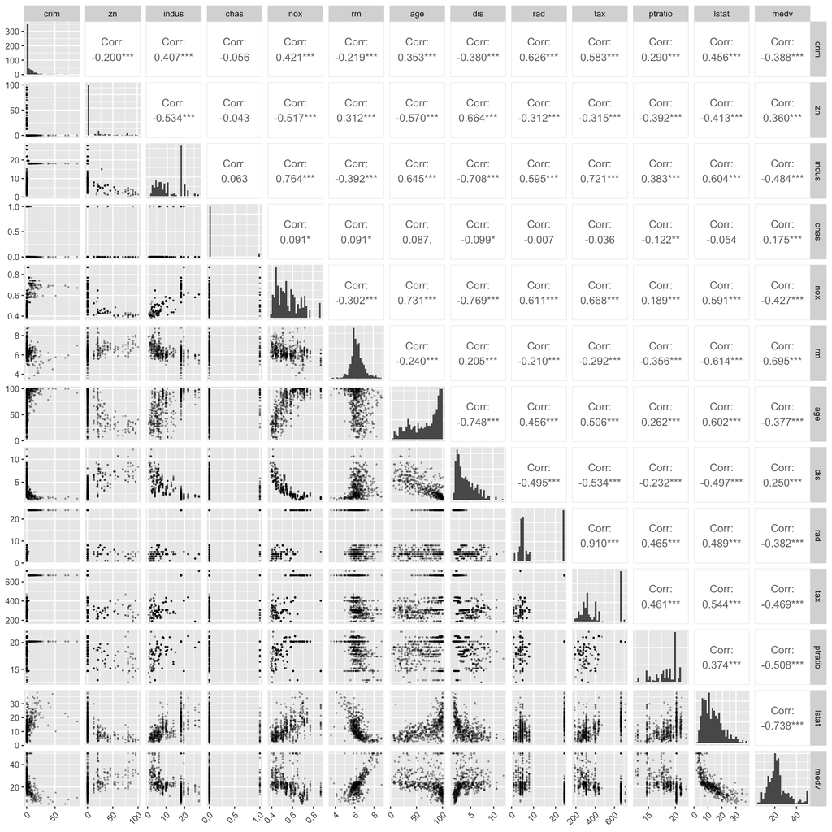

```r
library(GGally)
ggpairs(Boston, lower=list(continuous=wrap("points", alpha=0.3, size=0.3)),
        diag=list(continuous='barDiag')) +
  theme(axis.text.x = element_text(angle = 45, vjust = 1, hjust=1)) +
  scale_x_continuous(breaks = scales::pretty_breaks(n = 3)) +
  scale_y_continuous(breaks = scales::pretty_breaks(n = 3))
```

**(c) Are any of the predictors associated with per capita crime rate? If so, explain the relationship.**

**Answer:** Yes, `nox`, `age` and `lstat` are positively associated with per capita crime rate, and `dis` is negatively associated with per capita crime rate. It may indicate that the suburbs with higher nitrogen oxides concentration, higher proportion of units built prior to 1940 and higher percentage of lower status population have higher per capita crime rate, and the suburbs further away from Boston employment centres have lower per capita crime rate.

**(d) Do any of the census tracts of Boston appear to have particularly high crime rates? Tax rates? Pupil-teacher ratios? Comment on the range of each predictor.**

**Answer:**

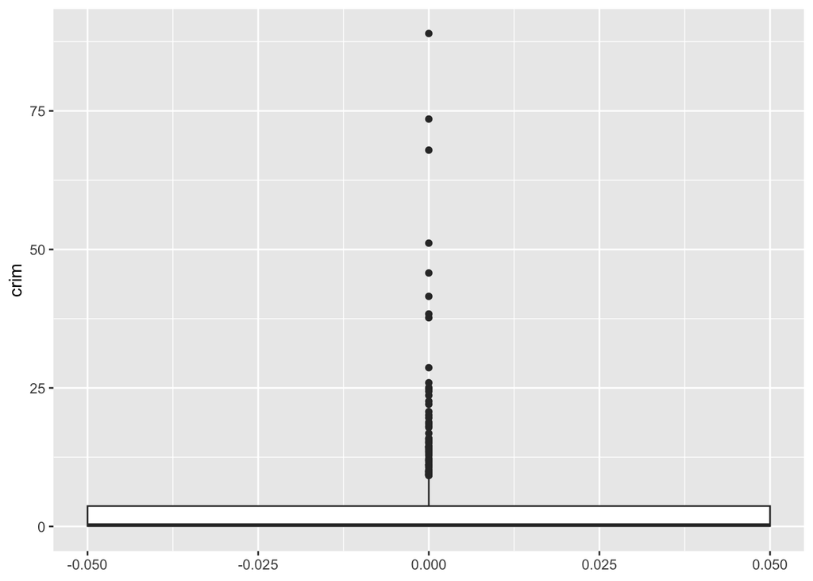

```r
library(ggplot2)
ggplot(Boston, aes(y=crim)) +
  geom_boxplot(width = 0.1)
```

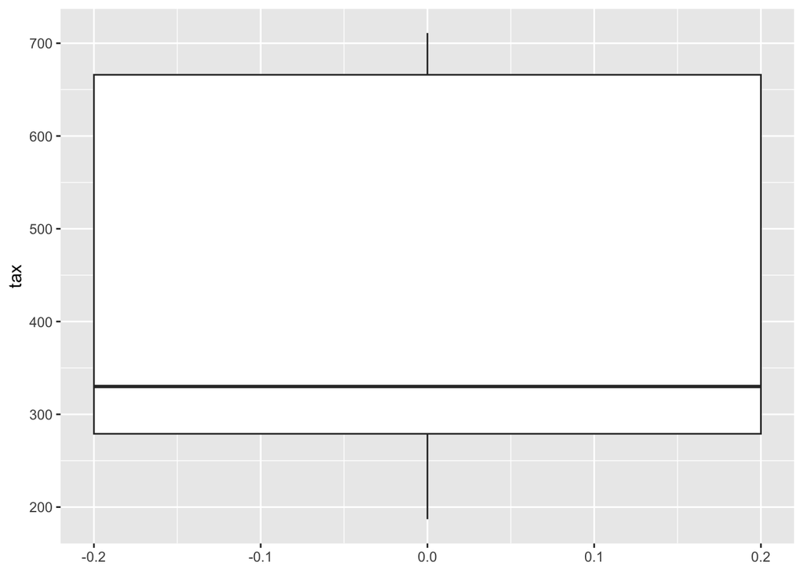

```r
ggplot(Boston, aes(y=tax)) +
  geom_boxplot(width = 0.4)
```

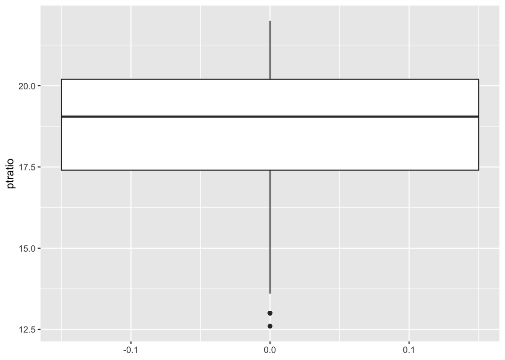

```r
ggplot(Boston, aes(y=ptratio)) +
  geom_boxplot(width = 0.3)
```

```r
Boston %>%
  select(crim, tax, ptratio) %>%
  summary()
```

```
      crim               tax           ptratio
 Min.   : 0.00632   Min.   :187.0   Min.   :12.60
 1st Qu.: 0.08205   1st Qu.:279.0   1st Qu.:17.40
 Median : 0.25651   Median :330.0   Median :19.05
 Mean   : 3.61352   Mean   :408.2   Mean   :18.46
 3rd Qu.: 3.67708   3rd Qu.:666.0   3rd Qu.:20.20
 Max.   :88.97620   Max.   :711.0   Max.   :22.00
```

- The range of `crim` is 0.00632 to 88.9762, the middle 50% of the data is 0.082045 to 3.677083.
- The range of `tax` is 187 to 711, the middle 50% of the data is 279 to 666.
- The range of `ptratio` is 12.6 to 22, the middle 50% of the data is 17.4 to 20.2.

**(e) How many of the census tracts in this data set bound the Charles river?**

**Answer:**

```r
Boston %>%
  filter(chas == 1) %>%
  nrow()
```

```
[1] 35
```

There are 35 census tracts in this data set bound the Charles river.

**(f) What is the median pupil-teacher ratio among the towns in this data set?**

**Answer:**

```r
median(Boston$ptratio)
```

```
[1] 19.05
```

The median pupil-teacher ratio among the towns in this data set is 19.05.

**(g) Which census tract of Boston has lowest median value of owner- occupied homes? What are the values of the other predictors for that census tract, and how do those values compare to the overall ranges for those predictors? Comment on your findings.**

**Answer:**

```r
Boston %>%
  filter(medv == min(medv))
```

```
# A tibble: 2 × 13
   crim    zn indus  chas   nox    rm   age   dis   rad   tax ptratio lstat
  <dbl> <dbl> <dbl> <dbl> <dbl> <dbl> <dbl> <dbl> <dbl> <dbl>   <dbl> <dbl>
1  38.4     0  18.1     0 0.693  5.45   100  1.49    24   666    20.2  30.6
2  67.9     0  18.1     0 0.693  5.68   100  1.43    24   666    20.2  23.0
# ℹ 1 more variable: medv <dbl>
```

Except `chas`, all others predictors are continuous, so we can calculate the quantile of the values in the census tract with lowest `medv`.

```r
continuous <- Boston %>%
  select(-chas)

# create a list of ecdf functions
ecdfs <- lapply(continuous, ecdf)

# find the census tract with lowest medv
selected_rows <- continuous[continuous$medv==min(continuous$medv),]

# calculate the quantile of the values in the census tract with lowest medv
quantiles <- mapply(function(f, column) f(column), ecdfs, selected_rows)
print(quantiles)
```

```
          crim        zn     indus       nox        rm age        dis rad
[1,] 0.9881423 0.7351779 0.8873518 0.8577075 0.0770751   1 0.05731225   1
[2,] 0.9960474 0.7351779 0.8873518 0.8577075 0.1363636   1 0.04150198   1
           tax   ptratio     lstat        medv
[1,] 0.9901186 0.8893281 0.9782609 0.003952569
[2,] 0.9901186 0.8893281 0.8992095 0.003952569
```

For dummy variable `chas`, we can calculate the proportion of census tracts with `chas` equal to 1 and 0.

```r
prop.table(table(Boston$chas))
```

```
         0          1
0.93083004 0.06916996
```

we can see that 93.1% of census tracts have `chas` equal to 0, and 6.9% of census tracts have `chas` equal to 1. So the census tract with lowest `medv` is in the majority group of `chas`, which is `chas` equal to 0.

**(h) In this data set, how many of the census tracts average more than seven rooms per dwelling? More than eight rooms per dwelling? Comment on the census tracts that average more than eight rooms per dwelling.**

**Answer:**

```r
Boston %>%
  filter(rm > 7) %>%
  nrow()
```

```
[1] 64
```

```r
Boston %>%
  filter(rm > 8) %>%
  nrow()
```

```
[1] 13
```

There are 64 census tracts average more than seven rooms per dwelling, and 13 census tracts average more than eight rooms per dwelling.

```r
Boston %>%
  filter(rm > 8)
```

```
# A tibble: 13 × 13
     crim    zn indus  chas   nox    rm   age   dis   rad   tax ptratio lstat
    <dbl> <dbl> <dbl> <dbl> <dbl> <dbl> <dbl> <dbl> <dbl> <dbl>   <dbl> <dbl>
 1 0.121      0  2.89     0 0.445  8.07  76    3.50     2   276    18    4.21
 2 1.52       0 19.6      1 0.605  8.38  93.9  2.16     5   403    14.7  3.32
 3 0.0201    95  2.68     0 0.416  8.03  31.9  5.12     4   224    14.7  2.88
 4 0.315      0  6.2      0 0.504  8.27  78.3  2.89     8   307    17.4  4.14
 5 0.527      0  6.2      0 0.504  8.72  83    2.89     8   307    17.4  4.63
 6 0.382      0  6.2      0 0.504  8.04  86.5  3.22     8   307    17.4  3.13
 7 0.575      0  6.2      0 0.507  8.34  73.3  3.84     8   307    17.4  2.47
 8 0.331      0  6.2      0 0.507  8.25  70.4  3.65     8   307    17.4  3.95
 9 0.369     22  5.86     0 0.431  8.26   8.4  8.91     7   330    19.1  3.54
10 0.612     20  3.97     0 0.647  8.70  86.9  1.80     5   264    13    5.12
11 0.520     20  3.97     0 0.647  8.40  91.5  2.29     5   264    13    5.91
12 0.578     20  3.97     0 0.575  8.30  67    2.42     5   264    13    7.44
13 3.47       0 18.1      1 0.718  8.78  82.9  1.90    24   666    20.2  5.29
# ℹ 1 more variable: medv <dbl>
```

```r
continuous <- Boston %>%
  select(-chas)

# create a list of ecdf functions
ecdfs <- lapply(continuous, ecdf)

# find the census tract with lowest medv
selected_rows <- continuous[continuous$rm>8,]

# calculate the quantile of the values in the census tract with lowest medv
quantiles <- mapply(function(f, column) f(column), ecdfs, selected_rows)
print(quantiles)
```

```
            crim        zn      indus        nox        rm        age       dis
 [1,] 0.34387352 0.7351779 0.10079051 0.21936759 0.9802372 0.48418972 0.5494071
 [2,] 0.69367589 0.7351779 0.94664032 0.70158103 0.9920949 0.74703557 0.2766798
 [3,] 0.03557312 0.9980237 0.09090909 0.09090909 0.9762846 0.14229249 0.7490119
 [4,] 0.52766798 0.7351779 0.35770751 0.39525692 0.9861660 0.50988142 0.4644269
 [5,] 0.58893281 0.7351779 0.35770751 0.39525692 0.9980237 0.55928854 0.4644269
 [6,] 0.56126482 0.7351779 0.35770751 0.39525692 0.9782609 0.60869565 0.5039526
 [7,] 0.60474308 0.7351779 0.35770751 0.41501976 0.9901186 0.46442688 0.5968379
 [8,] 0.53952569 0.7351779 0.35770751 0.41501976 0.9822134 0.44071146 0.5671937
 [9,] 0.55533597 0.8280632 0.29841897 0.14229249 0.9841897 0.01976285 0.9802372
[10,] 0.61067194 0.8003953 0.18181818 0.78458498 0.9960474 0.61067194 0.1501976
[11,] 0.58498024 0.8003953 0.18181818 0.78458498 0.9940711 0.69367589 0.3122530
[12,] 0.60671937 0.8003953 0.18181818 0.60079051 0.9881423 0.41106719 0.3458498
[13,] 0.74308300 0.7351779 0.88735178 0.92687747 1.0000000 0.55533597 0.1877470
             rad        tax    ptratio       lstat      medv
 [1,] 0.08695652 0.22332016 0.37549407 0.075098814 0.9367589
 [2,] 0.60671937 0.66798419 0.10079051 0.035573123 1.0000000
 [3,] 0.37944664 0.08695652 0.10079051 0.011857708 1.0000000
 [4,] 0.73913043 0.45454545 0.28458498 0.071146245 0.9565217
 [5,] 0.73913043 0.45454545 0.28458498 0.098814229 1.0000000
 [6,] 0.73913043 0.45454545 0.28458498 0.027667984 0.9328063
 [7,] 0.73913043 0.45454545 0.28458498 0.007905138 0.9426877
 [8,] 0.73913043 0.45454545 0.28458498 0.065217391 0.9644269
 [9,] 0.69169960 0.50592885 0.53359684 0.043478261 0.9466403
[10,] 0.60671937 0.17786561 0.02964427 0.132411067 1.0000000
[11,] 0.60671937 0.17786561 0.02964427 0.179841897 0.9683794
[12,] 0.60671937 0.17786561 0.02964427 0.280632411 1.0000000
[13,] 1.00000000 0.99011858 0.88932806 0.144268775 0.5474308
```

From the quantiles above, we know that the census tracts that average more than 8 rooms per dwelling have relatively high value in `zn`, `rad`, and `medv`, which means the proportion of residential land zoned for lots over 25,000 sq.ft., accessibility to radial highways and median value of owner-occupied homes are relatively high in those areas. And they have relatively low value in `indus`, `tax`, `ptratio` and `lstat`, which means the proportion of non-retail business, property-tax rate, pupil-teacher ratio and percentage of lower status of the population are relatively low in those areas. And most of them don’t bound to the Charles river.

**Python**

```python
import pandas as pd
import io
import requests

url = "https://raw.githubusercontent.com/ucla-econ-425t/2023winter/master/slides/data/Boston.csv"
s = requests.get(url).content
Boston = pd.read_csv(io.StringIO(s.decode('utf-8')), index_col = 0)
Boston
```

```
        crim    zn  indus  chas    nox  ...  rad  tax  ptratio  lstat  medv
1    0.00632  18.0   2.31     0  0.538  ...    1  296     15.3   4.98  24.0
2    0.02731   0.0   7.07     0  0.469  ...    2  242     17.8   9.14  21.6
3    0.02729   0.0   7.07     0  0.469  ...    2  242     17.8   4.03  34.7
4    0.03237   0.0   2.18     0  0.458  ...    3  222     18.7   2.94  33.4
5    0.06905   0.0   2.18     0  0.458  ...    3  222     18.7   5.33  36.2
..       ...   ...    ...   ...    ...  ...  ...  ...      ...    ...   ...
502  0.06263   0.0  11.93     0  0.573  ...    1  273     21.0   9.67  22.4
503  0.04527   0.0  11.93     0  0.573  ...    1  273     21.0   9.08  20.6
504  0.06076   0.0  11.93     0  0.573  ...    1  273     21.0   5.64  23.9
505  0.10959   0.0  11.93     0  0.573  ...    1  273     21.0   6.48  22.0
506  0.04741   0.0  11.93     0  0.573  ...    1  273     21.0   7.88  11.9

[506 rows x 13 columns]
```

## 5 ISL Exercise 3.7.3 (12pts)

**Answer:**

**(a)** option iii is true.

For a fixed value of IQ and GPA, high school graduates earn more, on average, than college graduates provided that the GPA is high enough. Because, for i and ii, we don what value of GPA is fixed at, so the starting salary is unsure. But, for iii and iv, as GPA is high enough, there exist a threshold beyong which the starting salary of high school graduates is higher than that of college graduates.

**(b)** When IQ = 110, GPA = 4.0, and Level = 1, the predicted salary is 137.1 thousand dollars.
$$Predicted\,Salary = 50 + 20 × 4.0 + 0.07 × 110 + 35 × 1 + 0.01 × 4.0 × 110 − 10 × 4.0 × 1 = 137.1$$
**(c)** False. Because the coefficient itself does not imply significancxe. We need to see the p-value of the coefficient to determine whether there is a significant evidence of the interaction effect.

## 6 ISL Exercise 3.7.15 (20pts)

```r
library(tidyverse)

Boston <- read_csv("https://raw.githubusercontent.com/ucla-biostat-212a/2024winter/master/slides/data/Boston.csv", col_select = -1) %>%
  print(width = Inf)
```

```
# A tibble: 506 × 13
      crim    zn indus  chas   nox    rm   age   dis   rad   tax ptratio lstat
     <dbl> <dbl> <dbl> <dbl> <dbl> <dbl> <dbl> <dbl> <dbl> <dbl>   <dbl> <dbl>
 1 0.00632  18    2.31     0 0.538  6.58  65.2  4.09     1   296    15.3  4.98
 2 0.0273    0    7.07     0 0.469  6.42  78.9  4.97     2   242    17.8  9.14
 3 0.0273    0    7.07     0 0.469  7.18  61.1  4.97     2   242    17.8  4.03
 4 0.0324    0    2.18     0 0.458  7.00  45.8  6.06     3   222    18.7  2.94
 5 0.0690    0    2.18     0 0.458  7.15  54.2  6.06     3   222    18.7  5.33
 6 0.0298    0    2.18     0 0.458  6.43  58.7  6.06     3   222    18.7  5.21
 7 0.0883   12.5  7.87     0 0.524  6.01  66.6  5.56     5   311    15.2 12.4
 8 0.145    12.5  7.87     0 0.524  6.17  96.1  5.95     5   311    15.2 19.2
 9 0.211    12.5  7.87     0 0.524  5.63 100    6.08     5   311    15.2 29.9
10 0.170    12.5  7.87     0 0.524  6.00  85.9  6.59     5   311    15.2 17.1
    medv
   <dbl>
 1  24
 2  21.6
 3  34.7
 4  33.4
 5  36.2
 6  28.7
 7  22.9
 8  27.1
 9  16.5
10  18.9
# ℹ 496 more rows
```

**(a) Fit simple linear regression model for each predictor.**

```r
reg_zn = lm (crim ~ zn , data = Boston)
summary(reg_zn)
```

```
Call:
lm(formula = crim ~ zn, data = Boston)

Residuals:
   Min     1Q Median     3Q    Max
-4.429 -4.222 -2.620  1.250 84.523

Coefficients:
            Estimate Std. Error t value Pr(>|t|)
(Intercept)  4.45369    0.41722  10.675  < 2e-16 ***
zn          -0.07393    0.01609  -4.594 5.51e-06 ***
---
Signif. codes:  0 '***' 0.001 '**' 0.01 '*' 0.05 '.' 0.1 ' ' 1

Residual standard error: 8.435 on 504 degrees of freedom
Multiple R-squared:  0.04019,   Adjusted R-squared:  0.03828
F-statistic:  21.1 on 1 and 504 DF,  p-value: 5.506e-06
```

```r
reg_indus = lm(crim ~ indus, data=Boston)
summary(reg_indus)
```

```
Call:
lm(formula = crim ~ indus, data = Boston)

Residuals:
    Min      1Q  Median      3Q     Max
-11.972  -2.698  -0.736   0.712  81.813

Coefficients:
            Estimate Std. Error t value Pr(>|t|)
(Intercept) -2.06374    0.66723  -3.093  0.00209 **
indus        0.50978    0.05102   9.991  < 2e-16 ***
---
Signif. codes:  0 '***' 0.001 '**' 0.01 '*' 0.05 '.' 0.1 ' ' 1

Residual standard error: 7.866 on 504 degrees of freedom
Multiple R-squared:  0.1653,    Adjusted R-squared:  0.1637
F-statistic: 99.82 on 1 and 504 DF,  p-value: < 2.2e-16
```

```r
reg_chas = lm(crim ~ chas, data=Boston)
summary(reg_chas)
```

```
Call:
lm(formula = crim ~ chas, data = Boston)

Residuals:
   Min     1Q Median     3Q    Max
-3.738 -3.661 -3.435  0.018 85.232

Coefficients:
            Estimate Std. Error t value Pr(>|t|)
(Intercept)   3.7444     0.3961   9.453   <2e-16 ***
chas         -1.8928     1.5061  -1.257    0.209
---
Signif. codes:  0 '***' 0.001 '**' 0.01 '*' 0.05 '.' 0.1 ' ' 1

Residual standard error: 8.597 on 504 degrees of freedom
Multiple R-squared:  0.003124,  Adjusted R-squared:  0.001146
F-statistic: 1.579 on 1 and 504 DF,  p-value: 0.2094
```

```r
reg_nox = lm(crim ~ nox, data=Boston)
summary(reg_nox)
```

```
Call:
lm(formula = crim ~ nox, data = Boston)

Residuals:
    Min      1Q  Median      3Q     Max
-12.371  -2.738  -0.974   0.559  81.728

Coefficients:
            Estimate Std. Error t value Pr(>|t|)
(Intercept)  -13.720      1.699  -8.073 5.08e-15 ***
nox           31.249      2.999  10.419  < 2e-16 ***
---
Signif. codes:  0 '***' 0.001 '**' 0.01 '*' 0.05 '.' 0.1 ' ' 1

Residual standard error: 7.81 on 504 degrees of freedom
Multiple R-squared:  0.1772,    Adjusted R-squared:  0.1756
F-statistic: 108.6 on 1 and 504 DF,  p-value: < 2.2e-16
```

```r
reg_rm = lm(crim ~ rm, data=Boston)
summary(reg_rm)
```

```
Call:
lm(formula = crim ~ rm, data = Boston)

Residuals:
   Min     1Q Median     3Q    Max
-6.604 -3.952 -2.654  0.989 87.197

Coefficients:
            Estimate Std. Error t value Pr(>|t|)
(Intercept)   20.482      3.365   6.088 2.27e-09 ***
rm            -2.684      0.532  -5.045 6.35e-07 ***
---
Signif. codes:  0 '***' 0.001 '**' 0.01 '*' 0.05 '.' 0.1 ' ' 1

Residual standard error: 8.401 on 504 degrees of freedom
Multiple R-squared:  0.04807,   Adjusted R-squared:  0.04618
F-statistic: 25.45 on 1 and 504 DF,  p-value: 6.347e-07
```

```r
reg_age = lm(crim ~ age, data=Boston)
summary(reg_age)
```

```
Call:
lm(formula = crim ~ age, data = Boston)

Residuals:
   Min     1Q Median     3Q    Max
-6.789 -4.257 -1.230  1.527 82.849

Coefficients:
            Estimate Std. Error t value Pr(>|t|)
(Intercept) -3.77791    0.94398  -4.002 7.22e-05 ***
age          0.10779    0.01274   8.463 2.85e-16 ***
---
Signif. codes:  0 '***' 0.001 '**' 0.01 '*' 0.05 '.' 0.1 ' ' 1

Residual standard error: 8.057 on 504 degrees of freedom
Multiple R-squared:  0.1244,    Adjusted R-squared:  0.1227
F-statistic: 71.62 on 1 and 504 DF,  p-value: 2.855e-16
```

```r
reg_dis = lm(crim ~ dis, data=Boston)
summary(reg_dis)
```

```
Call:
lm(formula = crim ~ dis, data = Boston)

Residuals:
   Min     1Q Median     3Q    Max
-6.708 -4.134 -1.527  1.516 81.674

Coefficients:
            Estimate Std. Error t value Pr(>|t|)
(Intercept)   9.4993     0.7304  13.006   <2e-16 ***
dis          -1.5509     0.1683  -9.213   <2e-16 ***
---
Signif. codes:  0 '***' 0.001 '**' 0.01 '*' 0.05 '.' 0.1 ' ' 1

Residual standard error: 7.965 on 504 degrees of freedom
Multiple R-squared:  0.1441,    Adjusted R-squared:  0.1425
F-statistic: 84.89 on 1 and 504 DF,  p-value: < 2.2e-16
```

```r
reg_rad = lm(crim ~ rad, data=Boston)
summary(reg_rad)
```

```
Call:
lm(formula = crim ~ rad, data = Boston)

Residuals:
    Min      1Q  Median      3Q     Max
-10.164  -1.381  -0.141   0.660  76.433

Coefficients:
            Estimate Std. Error t value Pr(>|t|)
(Intercept) -2.28716    0.44348  -5.157 3.61e-07 ***
rad          0.61791    0.03433  17.998  < 2e-16 ***
---
Signif. codes:  0 '***' 0.001 '**' 0.01 '*' 0.05 '.' 0.1 ' ' 1

Residual standard error: 6.718 on 504 degrees of freedom
Multiple R-squared:  0.3913,    Adjusted R-squared:   0.39
F-statistic: 323.9 on 1 and 504 DF,  p-value: < 2.2e-16
```

```r
reg_tax = lm(crim ~ tax, data=Boston)
summary(reg_tax)
```

```
Call:
lm(formula = crim ~ tax, data = Boston)

Residuals:
    Min      1Q  Median      3Q     Max
-12.513  -2.738  -0.194   1.065  77.696

Coefficients:
             Estimate Std. Error t value Pr(>|t|)
(Intercept) -8.528369   0.815809  -10.45   <2e-16 ***
tax          0.029742   0.001847   16.10   <2e-16 ***
---
Signif. codes:  0 '***' 0.001 '**' 0.01 '*' 0.05 '.' 0.1 ' ' 1

Residual standard error: 6.997 on 504 degrees of freedom
Multiple R-squared:  0.3396,    Adjusted R-squared:  0.3383
F-statistic: 259.2 on 1 and 504 DF,  p-value: < 2.2e-16
```

```r
reg_ptratio = lm(crim ~ ptratio, data=Boston)
summary(reg_ptratio)
```

```
Call:
lm(formula = crim ~ ptratio, data = Boston)

Residuals:
   Min     1Q Median     3Q    Max
-7.654 -3.985 -1.912  1.825 83.353

Coefficients:
            Estimate Std. Error t value Pr(>|t|)
(Intercept) -17.6469     3.1473  -5.607 3.40e-08 ***
ptratio       1.1520     0.1694   6.801 2.94e-11 ***
---
Signif. codes:  0 '***' 0.001 '**' 0.01 '*' 0.05 '.' 0.1 ' ' 1

Residual standard error: 8.24 on 504 degrees of freedom
Multiple R-squared:  0.08407,   Adjusted R-squared:  0.08225
F-statistic: 46.26 on 1 and 504 DF,  p-value: 2.943e-11
```

```r
reg_lstat = lm(crim ~ lstat, data=Boston)
summary(reg_lstat)
```

```
Call:
lm(formula = crim ~ lstat, data = Boston)

Residuals:
    Min      1Q  Median      3Q     Max
-13.925  -2.822  -0.664   1.079  82.862

Coefficients:
            Estimate Std. Error t value Pr(>|t|)
(Intercept) -3.33054    0.69376  -4.801 2.09e-06 ***
lstat        0.54880    0.04776  11.491  < 2e-16 ***
---
Signif. codes:  0 '***' 0.001 '**' 0.01 '*' 0.05 '.' 0.1 ' ' 1

Residual standard error: 7.664 on 504 degrees of freedom
Multiple R-squared:  0.2076,    Adjusted R-squared:  0.206
F-statistic:   132 on 1 and 504 DF,  p-value: < 2.2e-16
```

```r
reg_medv = lm(crim ~ medv, data=Boston)
summary(reg_medv)
```

```
Call:
lm(formula = crim ~ medv, data = Boston)

Residuals:
   Min     1Q Median     3Q    Max
-9.071 -4.022 -2.343  1.298 80.957

Coefficients:
            Estimate Std. Error t value Pr(>|t|)
(Intercept) 11.79654    0.93419   12.63   <2e-16 ***
medv        -0.36316    0.03839   -9.46   <2e-16 ***
---
Signif. codes:  0 '***' 0.001 '**' 0.01 '*' 0.05 '.' 0.1 ' ' 1

Residual standard error: 7.934 on 504 degrees of freedom
Multiple R-squared:  0.1508,    Adjusted R-squared:  0.1491
F-statistic: 89.49 on 1 and 504 DF,  p-value: < 2.2e-16
```

Summarize all the simple linear regression results in a dataframe:

```r
var_list = list("zn","indus","chas","nox","rm","age","dis","rad","tax","ptratio","lstat","medv")
df <- as.data.frame(matrix(NA, nrow =length(var_list) , ncol = 4))
names(df) <- c("Estimate","Std. Error","t value","Pr(>|t|)")
rownames(df) <- var_list

for (var in var_list){
  df[var,] <- summary(get(paste0("reg_",var)))$coefficients[2,]
}

print(df)
```

```
           Estimate  Std. Error   t value     Pr(>|t|)
zn      -0.07393498 0.016094596 -4.593776 5.506472e-06
indus    0.50977633 0.051024332  9.990848 1.450349e-21
chas    -1.89277655 1.506115484 -1.256727 2.094345e-01
nox     31.24853120 2.999190381 10.418989 3.751739e-23
rm      -2.68405122 0.532041083 -5.044819 6.346703e-07
age      0.10778623 0.012736436  8.462825 2.854869e-16
dis     -1.55090168 0.168330031 -9.213458 8.519949e-19
rad      0.61791093 0.034331820 17.998199 2.693844e-56
tax      0.02974225 0.001847415 16.099388 2.357127e-47
ptratio  1.15198279 0.169373609  6.801430 2.942922e-11
lstat    0.54880478 0.047760971 11.490654 2.654277e-27
medv    -0.36315992 0.038390175 -9.459710 1.173987e-19
```

Except for `chas`, the estimated beta of all the other predictors are significant at the 0.1% significance level.

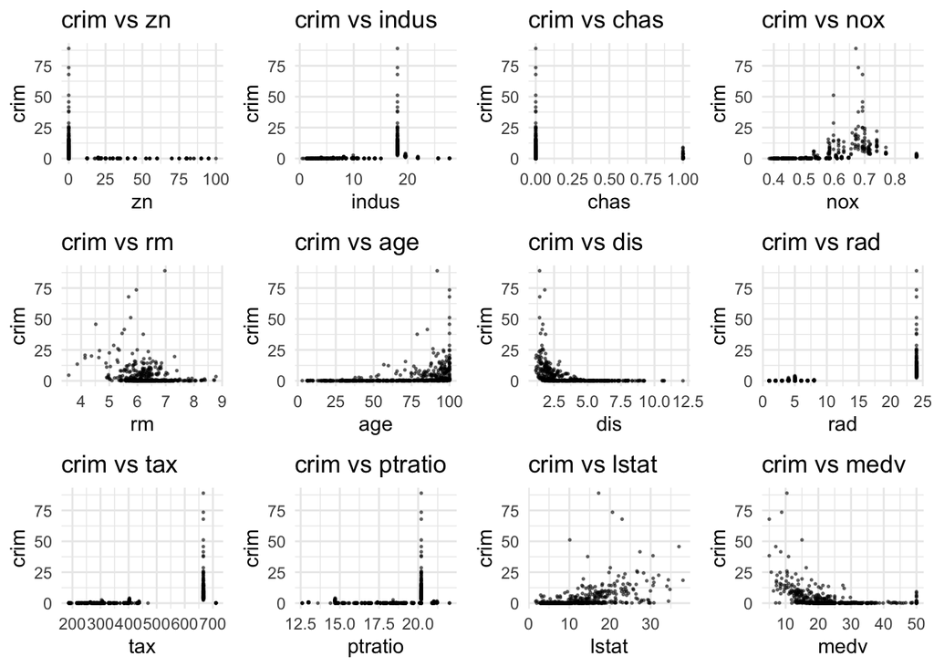

```r
library(ggplot2)
library(gridExtra)
plots_list <- list()
for (variable in names(Boston)) {
  if (variable != "crim") {
    p <- ggplot(Boston, aes_string(x = variable, y = "crim")) +
         geom_point(size=0.3,alpha=0.5) +
         theme_minimal() +
         ggtitle(paste("crim", "vs", variable))
    plots_list[[length(plots_list) + 1]] <- p
  }
}
do.call(gridExtra::grid.arrange, c(plots_list, ncol = 4))
```

From the point plots above, we can see that there are upward trends in `nox`, `age`, and `lstat`, and downward trends in `rm`, `dis`, and `medv`. The other predictors do not show obvious trends.

**(b) Fit a multiple regression model using all predictors.**

```r
reg_all = lm(crim ~ .-crim, data=Boston)
summary(reg_all)
```

```
Call:
lm(formula = crim ~ . - crim, data = Boston)

Residuals:
   Min     1Q Median     3Q    Max
-8.534 -2.248 -0.348  1.087 73.923

Coefficients:
              Estimate Std. Error t value Pr(>|t|)
(Intercept) 13.7783938  7.0818258   1.946 0.052271 .
zn           0.0457100  0.0187903   2.433 0.015344 *
indus       -0.0583501  0.0836351  -0.698 0.485709
chas        -0.8253776  1.1833963  -0.697 0.485841
nox         -9.9575865  5.2898242  -1.882 0.060370 .
rm           0.6289107  0.6070924   1.036 0.300738
age         -0.0008483  0.0179482  -0.047 0.962323
dis         -1.0122467  0.2824676  -3.584 0.000373 ***
rad          0.6124653  0.0875358   6.997 8.59e-12 ***
tax         -0.0037756  0.0051723  -0.730 0.465757
ptratio     -0.3040728  0.1863598  -1.632 0.103393
lstat        0.1388006  0.0757213   1.833 0.067398 .
medv        -0.2200564  0.0598240  -3.678 0.000261 ***
---
Signif. codes:  0 '***' 0.001 '**' 0.01 '*' 0.05 '.' 0.1 ' ' 1

Residual standard error: 6.46 on 493 degrees of freedom
Multiple R-squared:  0.4493,    Adjusted R-squared:  0.4359
F-statistic: 33.52 on 12 and 493 DF,  p-value: < 2.2e-16
```

**(c) How do your results from (a) compare to your results from (b)? Create a plot displaying the univariate regression coefficients from (a) on the x-axis, and the multiple regression coefficients from (b) on the y-axis. That is, each predictor is displayed as a single point in the plot. Its coefficient in a simple linear regres- sion model is shown on the x-axis, and its coefficient estimate in the multiple linear regression model is shown on the y-axis.**

*Answer:*

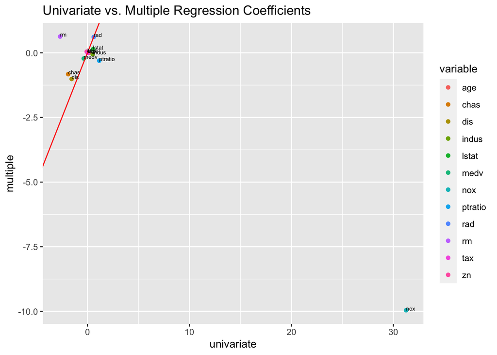

```r
library(ggplot2)
reg_coef <- data.frame(variable = names(Boston)[-1],
                       univariate = df$Estimate,
                       multiple = summary(reg_all)$coefficients[-1,1])
ggplot(reg_coef, aes(x = univariate, y = multiple)) +
  geom_point(aes(color = variable)) +
  geom_abline(intercept = 0, slope = 1, color = "red") +
  geom_text(aes(label = variable), hjust = 0, vjust = 0, size=2) +
  ggtitle("Univariate vs. Multiple Regression Coefficients")
```

From the plot above, we can see that most of the points are located around the red line, which means that the coefficients of most predictors in simple regression model are similar to the coefficients in multiple linear regression model. However, the coefficients of `rm` in multiple regression model are larger than the coefficients in simple linear regression model, and the coefficients of `nox` in multiple regression model are much smaller than the coefficients in simple linear regression model.

**(d) Is there evidence of non-linear association between any of the predictors and the response? To answer this question, for each predictor X, fit a model of the form**
$$Y = \beta_0 + \beta_1 X + \beta_2 X^2 + \beta_3 X^3 + \epsilon.$$

**Answer:** We don’t apply polynomial regression to `chas` because it is a dummy variable.

```r
poly_zn <- lm(crim ~ zn + I(zn^2) + I(zn^3), data = Boston)
summary(poly_zn)
```

```
Call:
lm(formula = crim ~ zn + I(zn^2) + I(zn^3), data = Boston)

Residuals:
   Min     1Q Median     3Q    Max
-4.821 -4.614 -1.294  0.473 84.130

Coefficients:
              Estimate Std. Error t value Pr(>|t|)
(Intercept)  4.846e+00  4.330e-01  11.192  < 2e-16 ***
zn          -3.322e-01  1.098e-01  -3.025  0.00261 **
I(zn^2)      6.483e-03  3.861e-03   1.679  0.09375 .
I(zn^3)     -3.776e-05  3.139e-05  -1.203  0.22954
---
Signif. codes:  0 '***' 0.001 '**' 0.01 '*' 0.05 '.' 0.1 ' ' 1

Residual standard error: 8.372 on 502 degrees of freedom
Multiple R-squared:  0.05824,   Adjusted R-squared:  0.05261
F-statistic: 10.35 on 3 and 502 DF,  p-value: 1.281e-06
```

```r
poly_indus <- lm(crim ~ indus + I(indus^2) + I(indus^3), data = Boston)
summary(poly_indus)
```

```
Call:
lm(formula = crim ~ indus + I(indus^2) + I(indus^3), data = Boston)

Residuals:
   Min     1Q Median     3Q    Max
-8.278 -2.514  0.054  0.764 79.713

Coefficients:
              Estimate Std. Error t value Pr(>|t|)
(Intercept)  3.6625683  1.5739833   2.327   0.0204 *
indus       -1.9652129  0.4819901  -4.077 5.30e-05 ***
I(indus^2)   0.2519373  0.0393221   6.407 3.42e-10 ***
I(indus^3)  -0.0069760  0.0009567  -7.292 1.20e-12 ***
---
Signif. codes:  0 '***' 0.001 '**' 0.01 '*' 0.05 '.' 0.1 ' ' 1

Residual standard error: 7.423 on 502 degrees of freedom
Multiple R-squared:  0.2597,    Adjusted R-squared:  0.2552
F-statistic: 58.69 on 3 and 502 DF,  p-value: < 2.2e-16
```

```r
poly_nox <- lm(crim ~ nox + I(nox^2) + I(nox^3), data = Boston)
summary(poly_nox)
```

```
Call:
lm(formula = crim ~ nox + I(nox^2) + I(nox^3), data = Boston)

Residuals:
   Min     1Q Median     3Q    Max
-9.110 -2.068 -0.255  0.739 78.302

Coefficients:
            Estimate Std. Error t value Pr(>|t|)
(Intercept)   233.09      33.64   6.928 1.31e-11 ***
nox         -1279.37     170.40  -7.508 2.76e-13 ***
I(nox^2)     2248.54     279.90   8.033 6.81e-15 ***
I(nox^3)    -1245.70     149.28  -8.345 6.96e-16 ***
---
Signif. codes:  0 '***' 0.001 '**' 0.01 '*' 0.05 '.' 0.1 ' ' 1

Residual standard error: 7.234 on 502 degrees of freedom
Multiple R-squared:  0.297, Adjusted R-squared:  0.2928
F-statistic: 70.69 on 3 and 502 DF,  p-value: < 2.2e-16
```

```r
poly_rm <- lm(crim ~ rm + I(rm^2) + I(rm^3), data = Boston)
summary(poly_rm)
```

```
Call:
lm(formula = crim ~ rm + I(rm^2) + I(rm^3), data = Boston)

Residuals:
    Min      1Q  Median      3Q     Max
-18.485  -3.468  -2.221  -0.015  87.219

Coefficients:
            Estimate Std. Error t value Pr(>|t|)
(Intercept) 112.6246    64.5172   1.746   0.0815 .
rm          -39.1501    31.3115  -1.250   0.2118
I(rm^2)       4.5509     5.0099   0.908   0.3641
I(rm^3)      -0.1745     0.2637  -0.662   0.5086
---
Signif. codes:  0 '***' 0.001 '**' 0.01 '*' 0.05 '.' 0.1 ' ' 1

Residual standard error: 8.33 on 502 degrees of freedom
Multiple R-squared:  0.06779,   Adjusted R-squared:  0.06222
F-statistic: 12.17 on 3 and 502 DF,  p-value: 1.067e-07
```

```r
poly_age <- lm(crim ~ age + I(age^2) + I(age^3), data = Boston)
summary(poly_age)
```

```
Call:
lm(formula = crim ~ age + I(age^2) + I(age^3), data = Boston)

Residuals:
   Min     1Q Median     3Q    Max
-9.762 -2.673 -0.516  0.019 82.842

Coefficients:
              Estimate Std. Error t value Pr(>|t|)
(Intercept) -2.549e+00  2.769e+00  -0.920  0.35780
age          2.737e-01  1.864e-01   1.468  0.14266
I(age^2)    -7.230e-03  3.637e-03  -1.988  0.04738 *
I(age^3)     5.745e-05  2.109e-05   2.724  0.00668 **
---
Signif. codes:  0 '***' 0.001 '**' 0.01 '*' 0.05 '.' 0.1 ' ' 1

Residual standard error: 7.84 on 502 degrees of freedom
Multiple R-squared:  0.1742,    Adjusted R-squared:  0.1693
F-statistic: 35.31 on 3 and 502 DF,  p-value: < 2.2e-16
```

```r
poly_dis <- lm(crim ~ dis + I(dis^2) + I(dis^3), data = Boston)
summary(poly_dis)
```

```
Call:
lm(formula = crim ~ dis + I(dis^2) + I(dis^3), data = Boston)

Residuals:
    Min      1Q  Median      3Q     Max
-10.757  -2.588   0.031   1.267  76.378

Coefficients:
            Estimate Std. Error t value Pr(>|t|)
(Intercept)  30.0476     2.4459  12.285  < 2e-16 ***
dis         -15.5543     1.7360  -8.960  < 2e-16 ***
I(dis^2)      2.4521     0.3464   7.078 4.94e-12 ***
I(dis^3)     -0.1186     0.0204  -5.814 1.09e-08 ***
---
Signif. codes:  0 '***' 0.001 '**' 0.01 '*' 0.05 '.' 0.1 ' ' 1

Residual standard error: 7.331 on 502 degrees of freedom
Multiple R-squared:  0.2778,    Adjusted R-squared:  0.2735
F-statistic: 64.37 on 3 and 502 DF,  p-value: < 2.2e-16
```

```r
poly_rad <- lm(crim ~ rad + I(rad^2) + I(rad^3), data = Boston)
summary(poly_rad)
```

```
Call:
lm(formula = crim ~ rad + I(rad^2) + I(rad^3), data = Boston)

Residuals:
    Min      1Q  Median      3Q     Max
-10.381  -0.412  -0.269   0.179  76.217

Coefficients:
             Estimate Std. Error t value Pr(>|t|)
(Intercept) -0.605545   2.050108  -0.295    0.768
rad          0.512736   1.043597   0.491    0.623
I(rad^2)    -0.075177   0.148543  -0.506    0.613
I(rad^3)     0.003209   0.004564   0.703    0.482

Residual standard error: 6.682 on 502 degrees of freedom
Multiple R-squared:    0.4, Adjusted R-squared:  0.3965
F-statistic: 111.6 on 3 and 502 DF,  p-value: < 2.2e-16
```

```r
poly_tax <- lm(crim ~ tax + I(tax^2) + I(tax^3), data = Boston)
summary(poly_tax)
```

```
Call:
lm(formula = crim ~ tax + I(tax^2) + I(tax^3), data = Boston)

Residuals:
    Min      1Q  Median      3Q     Max
-13.273  -1.389   0.046   0.536  76.950

Coefficients:
              Estimate Std. Error t value Pr(>|t|)
(Intercept)  1.918e+01  1.180e+01   1.626    0.105
tax         -1.533e-01  9.568e-02  -1.602    0.110
I(tax^2)     3.608e-04  2.425e-04   1.488    0.137
I(tax^3)    -2.204e-07  1.889e-07  -1.167    0.244

Residual standard error: 6.854 on 502 degrees of freedom
Multiple R-squared:  0.3689,    Adjusted R-squared:  0.3651
F-statistic:  97.8 on 3 and 502 DF,  p-value: < 2.2e-16
```

```r
poly_ptratio <- lm(crim ~ ptratio + I(ptratio^2) + I(ptratio^3), data = Boston)
summary(poly_ptratio)
```

```
Call:
lm(formula = crim ~ ptratio + I(ptratio^2) + I(ptratio^3), data = Boston)

Residuals:
   Min     1Q Median     3Q    Max
-6.833 -4.146 -1.655  1.408 82.697

Coefficients:
              Estimate Std. Error t value Pr(>|t|)
(Intercept)  477.18405  156.79498   3.043  0.00246 **
ptratio      -82.36054   27.64394  -2.979  0.00303 **
I(ptratio^2)   4.63535    1.60832   2.882  0.00412 **
I(ptratio^3)  -0.08476    0.03090  -2.743  0.00630 **
---
Signif. codes:  0 '***' 0.001 '**' 0.01 '*' 0.05 '.' 0.1 ' ' 1

Residual standard error: 8.122 on 502 degrees of freedom
Multiple R-squared:  0.1138,    Adjusted R-squared:  0.1085
F-statistic: 21.48 on 3 and 502 DF,  p-value: 4.171e-13
```

```r
poly_lstat <- lm(crim ~ lstat + I(lstat^2) + I(lstat^3), data = Boston)
summary(poly_lstat)
```

```
Call:
lm(formula = crim ~ lstat + I(lstat^2) + I(lstat^3), data = Boston)

Residuals:
    Min      1Q  Median      3Q     Max
-15.234  -2.151  -0.486   0.066  83.353

Coefficients:
              Estimate Std. Error t value Pr(>|t|)
(Intercept)  1.2009656  2.0286452   0.592   0.5541
lstat       -0.4490656  0.4648911  -0.966   0.3345
I(lstat^2)   0.0557794  0.0301156   1.852   0.0646 .
I(lstat^3)  -0.0008574  0.0005652  -1.517   0.1299
---
Signif. codes:  0 '***' 0.001 '**' 0.01 '*' 0.05 '.' 0.1 ' ' 1

Residual standard error: 7.629 on 502 degrees of freedom
Multiple R-squared:  0.2179,    Adjusted R-squared:  0.2133
F-statistic: 46.63 on 3 and 502 DF,  p-value: < 2.2e-16
```

```r
poly_medv <- lm(crim ~ medv + I(medv^2) + I(medv^3), data = Boston)
summary(poly_medv)
```

```
Call:
lm(formula = crim ~ medv + I(medv^2) + I(medv^3), data = Boston)

Residuals:
    Min      1Q  Median      3Q     Max
-24.427  -1.976  -0.437   0.439  73.655

Coefficients:
              Estimate Std. Error t value Pr(>|t|)
(Intercept) 53.1655381  3.3563105  15.840  < 2e-16 ***
medv        -5.0948305  0.4338321 -11.744  < 2e-16 ***
I(medv^2)    0.1554965  0.0171904   9.046  < 2e-16 ***
I(medv^3)   -0.0014901  0.0002038  -7.312 1.05e-12 ***
---
Signif. codes:  0 '***' 0.001 '**' 0.01 '*' 0.05 '.' 0.1 ' ' 1

Residual standard error: 6.569 on 502 degrees of freedom
Multiple R-squared:  0.4202,    Adjusted R-squared:  0.4167
F-statistic: 121.3 on 3 and 502 DF,  p-value: < 2.2e-16
```

Summarize all the polynomial regression results in a dataframe (except `chas`):

```r
var_list = list("zn","indus","nox","rm","age","dis","rad","tax","ptratio","lstat","medv")
df_poly <- as.data.frame(matrix(NA, nrow = length(var_list), ncol = 4))
colnames(df_poly) <- c("linear p value", "quadratic p value", "cubic p value", "R suqared")
names(df_poly) <- c("linear p value", "quadratic p value", "cubic p value", "R suqared")
rownames(df_poly) <- var_list

for (var in var_list){
  df_poly[var, 1] <- summary(get(paste0("poly_",var)))$coefficients[2,4]
  df_poly[var, 2] <- summary(get(paste0("poly_",var)))$coefficients[3,4]
  df_poly[var, 3] <- summary(get(paste0("poly_",var)))$coefficients[4,4]
  df_poly[var, 4] <- summary(get(paste0("poly_",var)))$r.squared
}

print(df_poly)
```

```
        linear p value quadratic p value cubic p value  R suqared
zn        2.612296e-03      9.375050e-02  2.295386e-01 0.05824197
indus     5.297064e-05      3.420187e-10  1.196405e-12 0.25965786
nox       2.758372e-13      6.811300e-15  6.961110e-16 0.29697790
rm        2.117564e-01      3.641094e-01  5.085751e-01 0.06778606
age       1.426608e-01      4.737733e-02  6.679915e-03 0.17423099
dis       6.374792e-18      4.941214e-12  1.088832e-08 0.27782477
rad       6.234175e-01      6.130099e-01  4.823138e-01 0.40003687
tax       1.097075e-01      1.374682e-01  2.438507e-01 0.36888208
ptratio   3.028663e-03      4.119552e-03  6.300514e-03 0.11378158
lstat     3.345300e-01      6.458736e-02  1.298906e-01 0.21793243
medv      2.637707e-28      3.260523e-18  1.046510e-12 0.42020026
```

## 7 Bonus question (20pts)

For multiple linear regression, show that $R^2$ is equal to the correlation between the response vector $\mathbf{y} = (y_1, \ldots, y_n)^T$ and the fitted values $\hat{\mathbf{y}} = (\hat y_1, \ldots, \hat y_n)^T$. That is
$$R^2 = 1 - \frac{\text{RSS}}{\text{TSS}} = [\operatorname{Cor}(\mathbf{y}, \hat{\mathbf{y}})]^2.$$

**Answer:**
$$\begin{align}
R^2 &= 1 - \frac{\text{RSS}}{\text{TSS}} \\
&= 1 - \frac{\sum_{i=1}^n (y_i - \hat y_i)^2}{\sum_{i=1}^n (y_i - \bar y)^2}
\end{align}$$
Let’s expand the TSS by plus and minus $\hat y_i$:
$$\begin{align}
TSS = \sum_{i=1}^n (y_i - \bar y)^2 &= \sum_{i=1}^n (y_i - \hat y_i + \hat y_i - \bar y)^2 \\
&= \sum_{i=1}^n (y_i - \hat y_i)^2 + \sum_{i=1}^n (\hat y_i - \bar y)^2 + 2 \sum_{i=1}^n (y_i - \hat y_i)(\hat y_i - \bar y) \\
&= \sum_{i=1}^n (y_i - \hat y_i)^2 + \sum_{i=1}^n (\hat y_i - \bar y)^2 + 2[\sum_{i=1}^n(y_i - \hat y_i)\hat y_i+\bar y\sum_{i=1}^n(y_i - \hat y_i)]\\
&= \sum_{i=1}^n (y_i - \hat y_i)^2 + \sum_{i=1}^n (\hat y_i - \bar y)^2
\end{align}$$
The term $\sum_{i=1}^n(y_i - \hat y_i)\hat y_i$ is zero because residuals are orthogonal to the predicted values, and $\sum_{i=1}^n(y_i - \hat y_i)$ is zero because the residuals sum to zero in linear regression. Thus, we can get:
$$\begin{align}
R^2 &= 1 - \frac{\sum_{i=1}^n (y_i - \hat y_i)^2}{\sum_{i=1}^n (y_i - \bar y)^2}\\
&=\frac{\sum_{i=1}^n (\hat y_i - \bar y)^2}{\sum_{i=1}^n (y_i - \bar y)^2}
\end{align}$$
We now focus on the squared correlation.

In linear regression, the mean of the response vector $\mathbf{y}$ is the same as the mean of the fitted values $\hat{\mathbf{y}}$, i.e., $\bar y = \bar{\hat y}$. Thus, we can get squared correlation between $\mathbf{y}$ and $\hat{\mathbf{y}}$:
$$\begin{align}
[\operatorname{Cor}(\mathbf{y}, \hat{\mathbf{y}})]^2 &= \left(\frac{\sum_{i=1}^n (y_i - \bar y)(\hat y_i - \bar y)}{\sqrt{\sum_{i=1}^n (y_i - \bar y)^2} \sqrt{\sum_{i=1}^n (\hat y_i - \bar y)^2}}\right)^2 \\
&= \frac{[\sum_{i=1}^n (y_i - \bar y)(\hat y_i - \bar y)]^2}{\sum_{i=1}^n (y_i - \bar y)^2 \sum_{i=1}^n (\hat y_i - \bar y)^2}
\end{align}$$
Plug in $y_i = \hat y_i + e_i$ (where $e_i = y_i - \hat y_i$), to the numerator, we have:
$$\begin{align}
numerator &= [\sum_{i=1}^n (\hat y_i + e_i - \bar y)(\hat y_i - \bar y)]^2\\
&= [\sum_{i=1}^n (\hat y_i - \bar y)^2 + \sum_{i=1}^n e_i(\hat y_i - \bar y)]^2\\
&= [\sum_{i=1}^n (\hat y_i - \bar y)^2 + \sum_{i=1}^n e_i\hat y_i - \bar y\sum_{i=1}^n e_i]^2\\
&= [\sum_{i=1}^n (\hat y_i - \bar y)^2]^2
\end{align}$$
Same as above, the term $\sum_{i=1}^n e_i\hat y_i$ is zero because residuals are orthogonal to the predicted values, and $\sum_{i=1}^n e_i$ is zero because the residuals sum to zero in linear regression. Then, plug back the numerator and eliminate the same term, we have:
$$\begin{align}
[\operatorname{Cor}(\mathbf{y}, \hat{\mathbf{y}})]^2 &= \frac{[\sum_{i=1}^n (\hat y_i - \bar y)^2]^2}{\sum_{i=1}^n (y_i - \bar y)^2 \sum_{i=1}^n (\hat y_i - \bar y)^2}\\
&= \frac{\sum_{i=1}^n (\hat y_i - \bar y)^2}{\sum_{i=1}^n (y_i - \bar y)^2}\\
&= R^2
\end{align}$$